# Splatter Simulations and Integration

Joey Hastings

2023-01-26

# Load Packages

```r
library(tictoc)
library(tidyverse)
library(cowplot)

library(splatter)
library(scater)
library(scran)
library(r.jive)
library(Seurat)
library(factoextra)
library(SLIDE)
```

# Simulation 1

## Generate Cell Counts

- Three cell types/groups (unbalanced)
- Two batches (balanced)
- Small dropout

```r
# Parameters that remain the same for all cell types
nGenes <- 5000
method = "single"
dropout.type = "experiment"
dropout.shape = -1
verbose = FALSE
```

```r
tic("Data Simulation")

# Simulation for first cell type
sim1a <- splatSimulate(
  # Parameters to remain the same for all simulations/cell types
  nGenes = nGenes,
  method = method,
  dropout.type = dropout.type,
  dropout.shape = dropout.shape,
  verbose = verbose,
  # Parameters to tweak in each simulation
  batchCells =     c(50, 50),
  batch.facLoc =   c(0.001, 0.5),
  batch.facScale = c(0.001, 0.5),
  dropout.mid = 0.05,
  # Parameters to tweak for each cell type
  seed = 1,
  de.prob = 0.01,
  de.downProb = 0.01,
  de.facLoc = 0.6,
  de.facScale = 0.1
)
sim1a_counts <- counts(sim1a)
sim1a_group <- rep("Group1", dim(sim1a_counts)[2])
sim1a_batch <- colData(sim1a)$Batch

# Simulation for second cell type
sim1b <- splatSimulate(
  # Parameters to remain the same for all simulations/cell types
  nGenes = nGenes,
  method = method,
  dropout.type = "experiment",
  dropout.shape = -1,
  verbose = FALSE,
  # Parameters to tweak in each simulation
  batchCells = c(150, 150),
  batch.facLoc = c(0.001, 0.5),
  batch.facScale = c(0.001, 0.5),
  dropout.mid = 0.05,
  # Parameters to tweak for each cell type
  seed = 2,
  de.prob = 0.1,
  de.downProb = 0.4,
  de.facLoc = 1,
  de.facScale = 0.4,
)

sim1b_counts <- counts(sim1b)
sim1b_group <- rep("Group2", dim(sim1b_counts)[2])
sim1b_batch <- colData(sim1b)$Batch

# Simulation for third cell type
sim1c <- splatSimulate(
  # Parameters to remain the same for all simulations/cell types
  nGenes = nGenes,
  method = method,
  dropout.type = dropout.type,
  dropout.shape = dropout.shape,
  verbose = verbose,
    # Parameters to tweak in each simulation
  batchCells = c(300, 300),
  batch.facLoc = c(0.001, 0.5),
  batch.facScale = c(0.001, 0.5),
  dropout.mid = 0.05,
  # Parameters to remain the same
  seed = 3,
  de.prob = 0.5,
  de.downProb = 0.9,
  de.facLoc = 0.2,
  de.facScale = 0.8
)

sim1c_counts <- counts(sim1c)
sim1c_group <- rep("Group3", dim(sim1c_counts)[2])
sim1c_batch <- colData(sim1c)$Batch
toc()
```

```
## Data Simulation: 5.49 sec elapsed
```

```r
# Combine cell types into unified count matrix
sim1_counts <- cbind(sim1a_counts, sim1b_counts, sim1c_counts)
colnames(sim1_counts) <- paste0("Cell", 1:ncol(sim1_counts))
sim1_group <- c(sim1a_group, sim1b_group, sim1c_group)
sim1_batch <- c(sim1a_batch, sim1b_batch, sim1c_batch)

# Create SCE object using unified count matrix, cell names, cell types, and batch numbers
sim1 <- SingleCellExperiment(list(counts = sim1_counts))
colData(sim1)$Cell <- paste0("Cell", 1:ncol(sim1_counts))
colData(sim1)$Group <- sim1_group
colData(sim1)$Batch <- sim1_batch
```

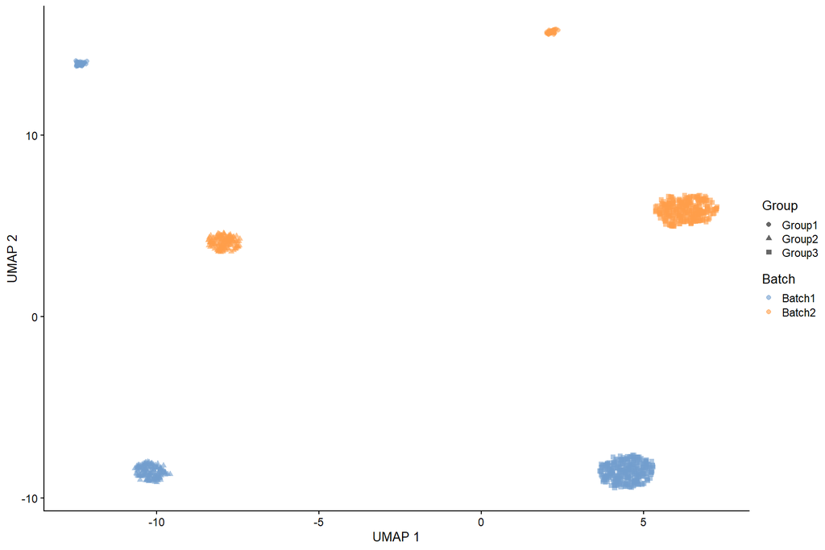

```r
sim1 <- logNormCounts(sim1)

# Dimension reduction visualization
set.seed(1)
sim1 <- runUMAP(sim1)
orig_p1 <- plotUMAP(sim1, color_by = "Batch", shape_by = "Group")
orig_p1
```

## Separate Batches

```r
batches <- sim1$Batch
# Frequency of batches in simulation
table(batches)
```

```
## batches
## Batch1 Batch2
##    500    500
```

```r
groups <- sim1$Group
# Frequency of cell types in simulation
table(groups)
```

```
## groups
## Group1 Group2 Group3
##    100    300    600
```

```r
rawcounts <- counts(sim1)
dim(rawcounts)
```

```
## [1] 5000 1000
```

```r
b1 <- rawcounts[, batches == "Batch1"]
grp_b1 <- groups[batches == "Batch1"]
# Dimension of batch 1
dim(b1)
```

```
## [1] 5000  500
```

```r
# Frequency of cell types in batch 1
table(grp_b1)
```

```
## grp_b1
## Group1 Group2 Group3
##     50    150    300
```

```r
b2 <- rawcounts[, batches == "Batch2"]
grp_b2 <- groups[batches == "Batch2"]
# Dimension of batch 2
dim(b2)
```

```
## [1] 5000  500
```

```r
# Frequency of cell types in batch 2
table(grp_b2)
```

```
## grp_b2
## Group1 Group2 Group3
##     50    150    300
```

## Compare Batches

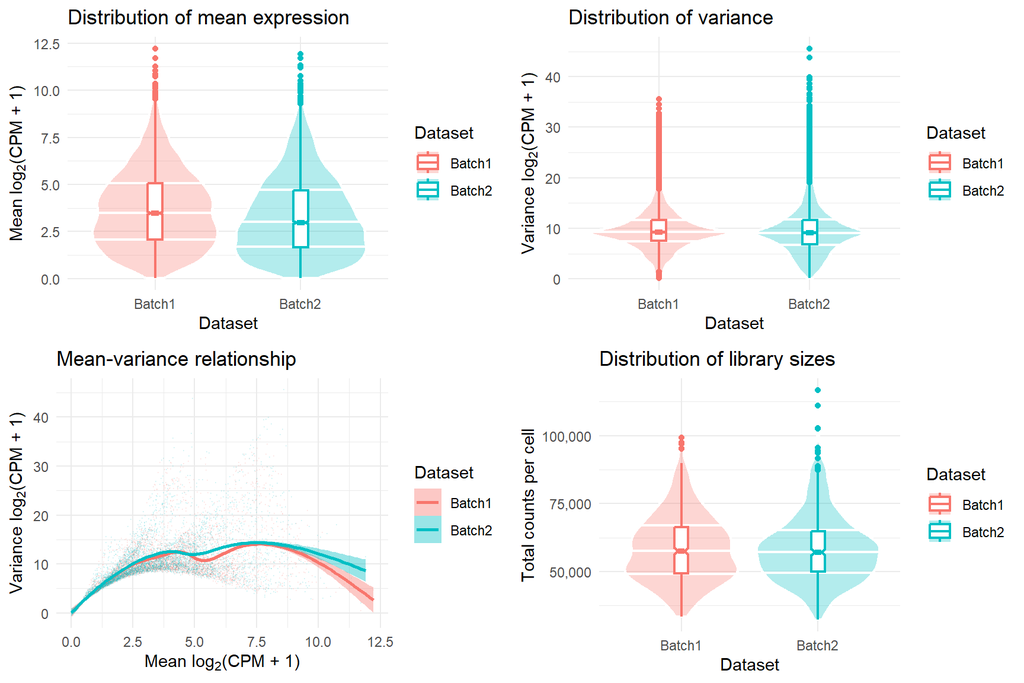

```r
# Convert count matrices for batch 1 and 2 in to SCE objects for comparison via splatter
b1_sce <- SingleCellExperiment(list(counts = b1))
b2_sce <- SingleCellExperiment(list(counts = b2))

comparison <- compareSCEs(
  list(
    Batch1 = b1_sce,
    Batch2 = b2_sce
    )
  )

plot_grid(plotlist = comparison$Plots[1:4])
```

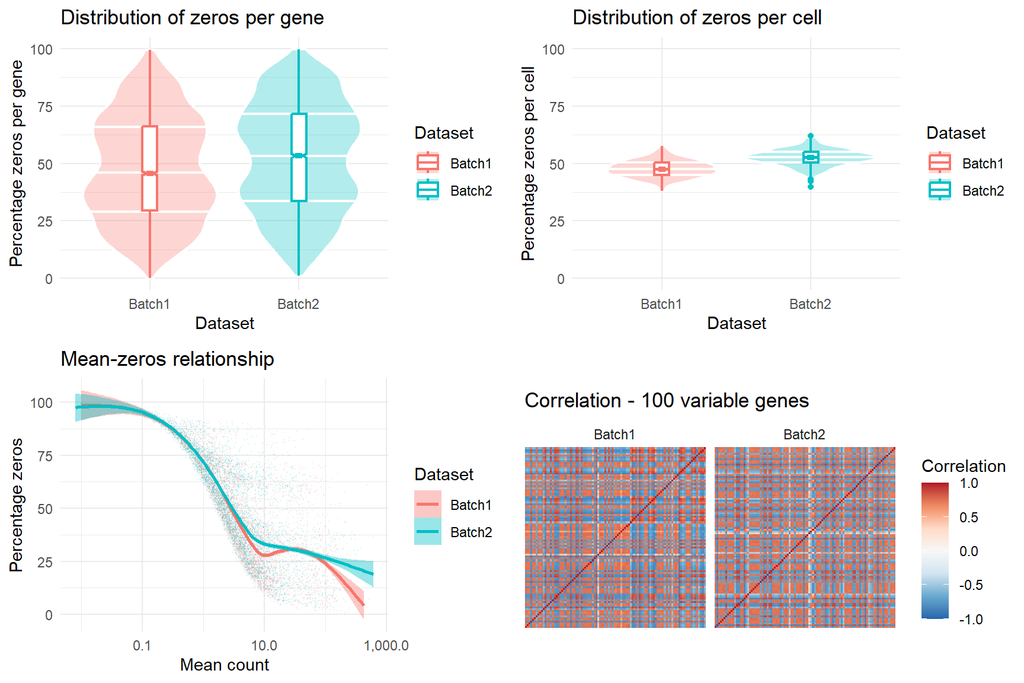

```r
plot_grid(plotlist = comparison$Plots[5:8])
```

## Seurat

Perform cell batch integration as in their tutorial.

### Setup

- Create Seurat objects for each batch
  - Assign metadata to each object (batch number, cell type)
- Normalize the cell counts
- Identify most variable features (genes)
- Choose most variable features from both batches for use in integration

```r
b1_seurat <- CreateSeuratObject(counts = b1, project = "simulation")
b1_seurat <- AddMetaData(b1_seurat, "Batch 1", col.name = "BatchNum")
b1_seurat <- AddMetaData(b1_seurat, grp_b1, col.name = "Group")

b2_seurat <- CreateSeuratObject(counts = b2, project = "simulation")
b2_seurat <- AddMetaData(b2_seurat, "Batch 2", col.name = "BatchNum")
b2_seurat <- AddMetaData(b2_seurat, grp_b2, col.name = "Group")

seurat_list <- list(Batch1 = b1_seurat, Batch2 = b2_seurat)

# normalize and identify variable features for each dataset independently
seurat_list <- lapply(X = seurat_list, FUN = function(x) {
    x <- NormalizeData(x)
    x <- FindVariableFeatures(x, selection.method = "vst", nfeatures = 2000)
})

# select features that are repeatedly variable across datasets for integration
features <- SelectIntegrationFeatures(object.list = seurat_list)
```

### Integration

- Perform integration by finding a set of anchors from the two batches (via CCA)
- Use the anchor list to integrate the two batches

```r
anchors <- FindIntegrationAnchors(object.list = seurat_list, anchor.features = features)
```

```
## Scaling features for provided objects
```

```
## Finding all pairwise anchors
```

```
## Running CCA
```

```
## Merging objects
```

```
## Finding neighborhoods
```

```
## Finding anchors
```

```
##  Found 1776 anchors
```

```
## Filtering anchors
```

```
##  Retained 1535 anchors
```

```r
combined <- IntegrateData(anchorset = anchors)
```

```
## Merging dataset 2 into 1
```

```
## Extracting anchors for merged samples
```

```
## Finding integration vectors
```

```
## Finding integration vector weights
```

```
## Integrating data
```

```r
GetAssay(combined, "integrated")
```

```
## Assay data with 2000 features for 1000 cells
## Top 10 variable features:
##  Gene1659, Gene3021, Gene603, Gene2500, Gene3417, Gene2836, Gene4542,
## Gene2867, Gene3277, Gene1352
```

### Integrated Analysis

- Integrated/combined data is centered/scaled
- First 30 PCs are computed/stored
- PC1-PC30 are used to perform t-SNE and UMAP dimensionality reduction
- Calculates k-nearest neighbors (`k = 20` by default) from PC1-PC30
- Identify clusters by using Shared Nearest Neighbors (SNN):
  - “First calculate k-nearest neighbors and construct the SNN graph”
  - “Then optimize the modularity function to determine clusters”

```r
# specify that we will perform downstream analysis on the corrected data note that the
# original unmodified data still resides in the 'RNA' assay
DefaultAssay(combined) <- "integrated"

# Run the standard workflow for visualization and clustering
set.seed(1)
combined <- ScaleData(combined, verbose = FALSE)
combined <- RunPCA(combined, npcs = 30, verbose = FALSE)
combined <- RunTSNE(combined, reduction = "pca", dims = 1:30)
combined <- RunUMAP(combined, reduction = "pca", dims = 1:30)
```

```
## 21:52:07 Found 3 connected components, falling back to 'spca' initialization with init_sdev = 1
## 21:52:07 PCA: 2 components explained 93.27% variance
## 21:52:07 Scaling init to sdev = 1
```

```r
combined <- FindNeighbors(combined, reduction = "pca", dims = 1:30)
combined <- FindClusters(combined, resolution = 0.5)
```

```
## Modularity Optimizer version 1.3.0 by Ludo Waltman and Nees Jan van Eck
##
## Number of nodes: 1000
## Number of edges: 89302
##
## Running Louvain algorithm...
## Maximum modularity in 10 random starts: 0.7827
## Number of communities: 3
## Elapsed time: 0 seconds
```

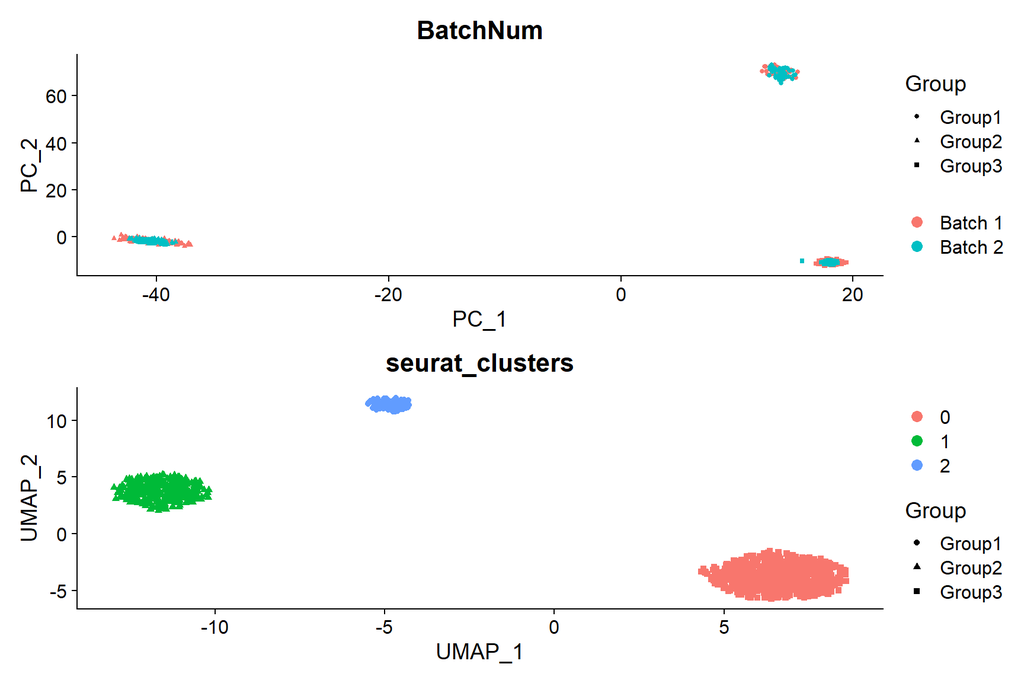

```r
# Visualization
seurat_p1 <- DimPlot(combined, reduction = "pca", group.by = "BatchNum", shape.by = "Group")
seurat_p2 <- DimPlot(combined, reduction = "umap", group.by = "seurat_clusters", shape.by = "Group", pt.size = 1.5)
seurat_p1 / seurat_p2
```

```r
# Frequency of true cell types/groups vs. identified clusters
table(combined@meta.data[, c("Group", "seurat_clusters")])
```

```
##         seurat_clusters
## Group      0   1   2
##   Group1   0   0 100
##   Group2   0 300   0
##   Group3 600   0   0
```

## JIVE

Multiple approaches to rank estimation:

- Permutation method (`JIVE_results_default`)
- Pre-specifying a joint rank of 2 (individuals ranks default to 1, respectively)
- BIC method

````r
#```{r jive1}
sim1_data <- NULL
sim1_data$Batch1 <- b1
sim1_data$Batch2 <- b2

set.seed(1)
tic("JIVE Analysis")
JIVE_results_default <- jive(sim1_data) # 26min runtime
JIVE_results_j2 <- jive(sim1_data, method = "given", rankJ = 2)
JIVE_results_bic <- jive(sim1_data, method = "bic") # multiple hours
toc()

saveRDS(JIVE_results_default, file = "JIVE_results_default.rds")
saveRDS(JIVE_results_j2, file = "JIVE_results_j2.rds")
saveRDS(JIVE_results_bic, file = "JIVE_results_bic.rds")
````

Summary of estimated ranks and variance explained by joint/individual/residual for each approach:

```r
JIVE_results_default <- readRDS(file = "JIVE_results_default.rds")
summary(JIVE_results_default)
```

```
## $Method
## [1] "perm"
##
## $Ranks
##      Source   Rank
## [1,] "Joint"  "1"
## [2,] "Batch1" "2"
## [3,] "Batch2" "3"
##
## $Variance
##            Batch1 Batch2
## Joint       0.655  0.599
## Individual  0.251  0.116
## Residual    0.094  0.285
```

```r
JIVE_results_j2 <- readRDS(file = "JIVE_results_j2.rds")
summary(JIVE_results_j2)
```

```
## $Method
## [1] "given"
##
## $Ranks
##      Source   Rank
## [1,] "Joint"  "2"
## [2,] "Batch1" "1"
## [3,] "Batch2" "1"
##
## $Variance
##            Batch1 Batch2
## Joint       0.868  0.862
## Individual  0.036  0.057
## Residual    0.096  0.081
```

```r
JIVE_results_bic <- readRDS(file = "JIVE_results_bic.rds")
summary(JIVE_results_bic)
```

```
## $Method
## [1] "bic"
##
## $Ranks
##      Source   Rank
## [1,] "Joint"  "3"
## [2,] "Batch1" "2"
## [3,] "Batch2" "1"
##
## $Variance
##            Batch1 Batch2
## Joint       0.841  0.902
## Individual  0.074  0.037
## Residual    0.084  0.061
```

BIC method results chosen for analysis:

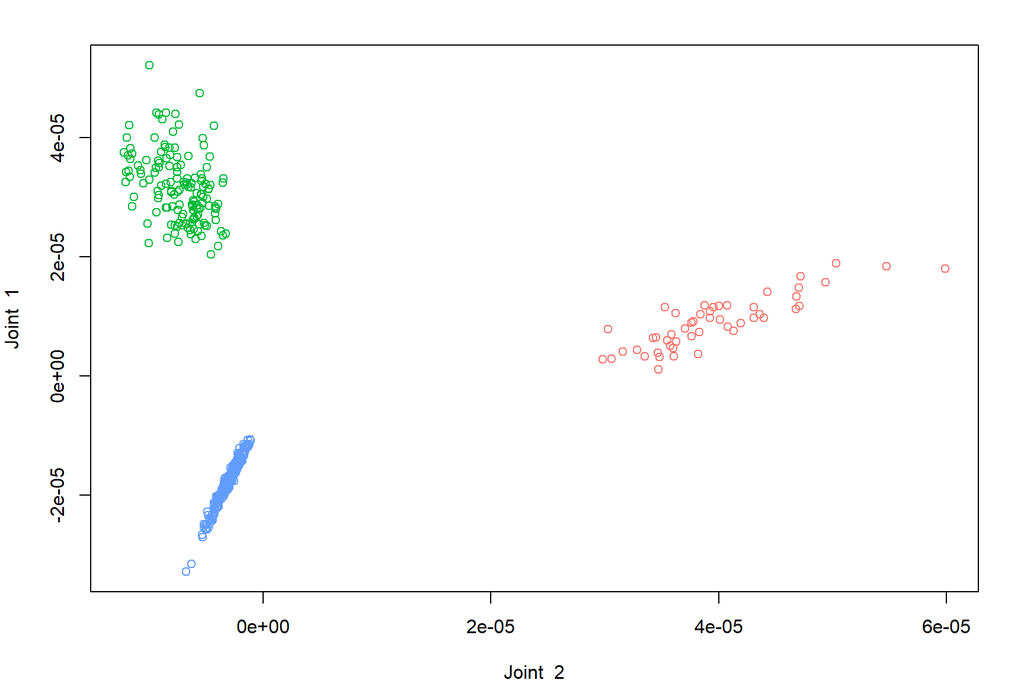

```r
# Choose model
# JIVE_results <- JIVE_results_default
# JIVE_results <- JIVE_results_j2
JIVE_results <- JIVE_results_bic

# Vector to color each cell type/group
jive_pca_col <- case_when(
  grp_b1 == "Group1" ~ scales::hue_pal()(3)[1],
  grp_b1 == "Group2" ~ scales::hue_pal()(3)[2],
  grp_b1 == "Group3" ~ scales::hue_pal()(3)[3],
)

# First PC for joint structures from batch 1 (x-axis) vs. batch 2 (y-axis)
showPCA(JIVE_results, n_joint = 2, Colors = jive_pca_col)
```

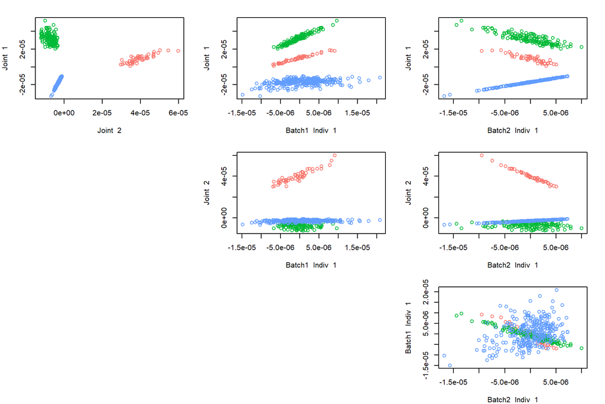

```r
# First PC for joint/individual structures vs. each other
showPCA(JIVE_results, n_joint = 2, n_indiv = c(1, 1), Colors = jive_pca_col)
```

First attempt at clustering using `scater` package:

- Row bind joint structure data from batch 1 and 2 into an SCE object
  - **POTENTIAL ISSUE:** the combined joint structure is assigned as a `logcounts` array within the SCE object, which is not necessarily true. Is it possible to transform the joint structures (or individual for that matter) back to original scale?
  - Assign true cell types/groups to object
- Perform PCA, obtaining first 30 PCs for the top 2000 most variable features
- Perform t-SNE/UMAP dimensionality reduction
- Cluster cells using a SNN algorithm
  - `louvain` clustering function used with `resolution = 0.5` (same as in Seurat above)

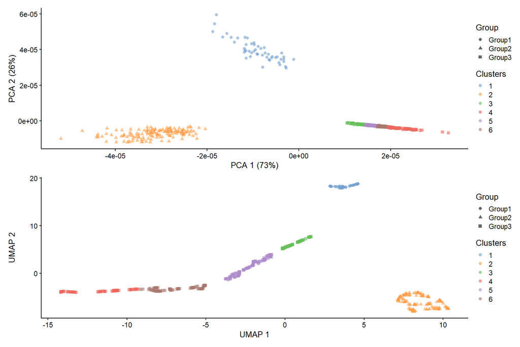

```r
# JIVE_joint_b1 <- SingleCellExperiment(list(logcounts = JIVE_results$joint[[1]]))
# colData(JIVE_joint_b1)$Group <- grp_b1
# colData(JIVE_joint_b1)$BatchNum <- "Batch1"
#
# JIVE_joint_b2 <- SingleCellExperiment(list(logcounts = JIVE_results$joint[[2]]))
# colData(JIVE_joint_b2)$Group <- grp_b2
# colData(JIVE_joint_b2)$BatchNum <- "Batch2"
#
# JIVE_joint_sce <- cbind(JIVE_joint_b1, JIVE_joint_b2)

# JIVE_joint <- cbind(JIVE_results$joint[[1]], JIVE_results$joint[[2]])
#
# JIVE_joint_sce <- SingleCellExperiment(list(logcounts = JIVE_joint))
# colData(JIVE_joint_sce)$Group <- c(grp_b1, grp_b2)
# colData(JIVE_joint_sce)$BatchNum <- c(rep("Batch1", 500), rep("Batch2", 500))

JIVE_joint <- rbind(JIVE_results$joint[[1]], JIVE_results$joint[[2]])

JIVE_joint_sce <- SingleCellExperiment(list(logcounts = JIVE_joint))
colData(JIVE_joint_sce)$Group <- grp_b1

set.seed(1)
JIVE_joint_sce <- runPCA(JIVE_joint_sce, ncomponents = 30, ntop = 2000)
JIVE_joint_sce <- runTSNE(JIVE_joint_sce)
JIVE_joint_sce <- runUMAP(JIVE_joint_sce)

clusters <- clusterCells(
  JIVE_joint_sce,
  use.dimred = "PCA",
  BLUSPARAM = bluster::SNNGraphParam(
    cluster.fun = "louvain",
    cluster.args = list(resolution = 0.5)
    )
  )
colData(JIVE_joint_sce)$Clusters <- clusters
jive_p1 <- plotPCA(JIVE_joint_sce, color_by = "Clusters", shape_by = "Group")
jive_p2 <- plotUMAP(JIVE_joint_sce, color_by = "Clusters", shape_by = "Group")
jive_p1 / jive_p2
```

Second attempt at clustering will only attempt at using the first PC from each joint structure:

- Calculate first PC from joint structure in batch 1/batch 2
- Determine $k$ for k-means clustering
  - Check how total within-sum-of-squares (`wss`) changes as $k$ increases
- Use `k=3` means to determine clusters

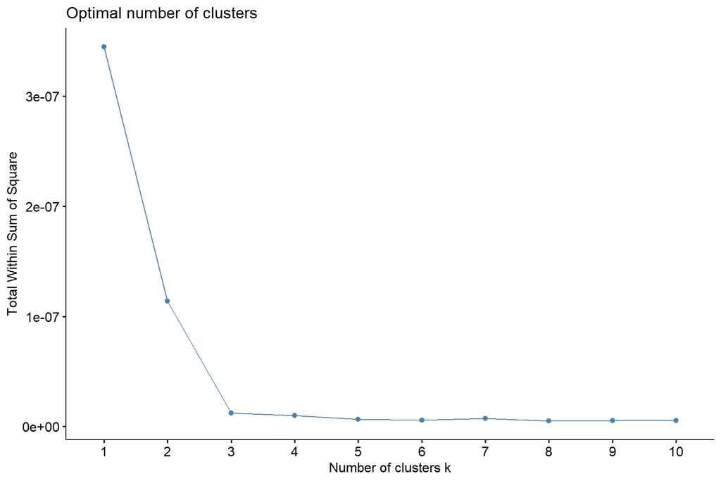

```r
result <- JIVE_results
n_joint <- 2
n_indiv <- c(0, 0)
nPCs <- n_joint + sum(n_indiv)
PCs <- matrix(nrow = nPCs, ncol = dim(result$data[[1]])[2])
PC_names <- rep("", nPCs)

SVD <- svd(do.call(rbind, result$joint), nu = n_joint, nv = n_joint)
PCs[1:n_joint, ] <- diag(SVD$d)[1:n_joint, 1:n_joint] %*% t(SVD$v[, 1:n_joint])
PC_names[1:n_joint] <- paste("Joint ", 1:n_joint)

PCs_df <- data.frame(t(PCs))
colnames(PCs_df) <-  c("PC1_Batch1", "PC1_Batch2")
rownames(PCs_df) <- paste0("Cell", 1:nrow(PCs_df))

# Find reasonable number of clusters (k) with an Elbow-plot
fviz_nbclust(PCs_df, kmeans, method = "wss")
```

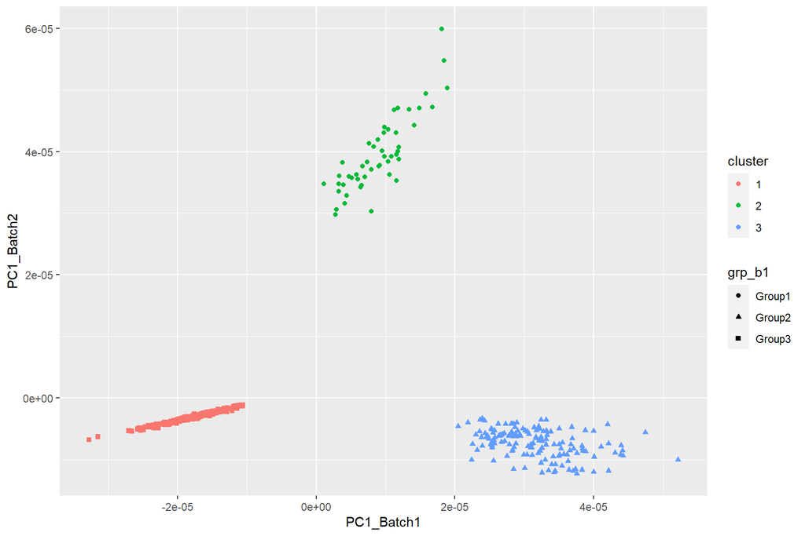

```r
clust <- kmeans(PCs_df, 3)

PCs_df_long <- PCs_df %>%
  rownames_to_column(var = "Cell") %>%
  cbind(grp_b1, cluster = factor(clust$cluster))

PCs_df_long %>%
  ggplot() +
  geom_point(aes(x = PC1_Batch1, y = PC1_Batch2, color = cluster, shape = grp_b1))
```

## SLIDE

```r
t_b1 <- t(b1)
t_b2 <- t(b2)
X <- cbind(t_b1, t_b2)
p1 <- ncol(t_b1)
p2 <- ncol(t_b2)

tic("SLIDE Analysis")
SLIDE_results <- slide(X = X, pvec = c(p1,p2)) # ~1H45M run time
toc()

saveRDS(SLIDE_results, file = "SLIDE_results.rds")
```

```r
SLIDE_results <- readRDS(file = "SLIDE_results.rds")

# n: number of cells
# p: number of genes
# r: rank (?)

# Score matrix U (n by r)
dim(SLIDE_results[["model"]][["U"]])
```

```
## [1] 500   6
```

```r
# Loading matrix V (p by r)
dim(SLIDE_results[["model"]][["V"]])
```

```
## [1] 10000     6
```

```r
# Block-sparse structure of V (d by r)
SLIDE_results[["S"]]
```

```
##      [,1] [,2] [,3] [,4] [,5] [,6]
## [1,]    1    1    0    1    0    1
## [2,]    1    1    1    0    1    0
```

```r
dim(SLIDE_results[["S"]])
```

```
## [1] 2 6
```